# 158.755 Project1

### by Yuan Gao 20003615

```python
import matplotlib.pyplot as plt
import pandas as pd
import numpy as np
import seaborn as sns
from pylab import rcParams
import re
import math
from matplotlib.pyplot import MultipleLocator
import scipy.stats as stats
```

```python
pd.set_option('max_columns', 30)
pd.set_option('max_rows', 30)

rcParams['figure.figsize'] = 15, 10
rcParams['font.size'] = 10
```

# Abstract

The main modules used are: pandas, matplotlib, seaborn. After completing this project, the relationship between players'position and different features is obtained.

# Introduction

FIFA 19 is a football simulation video game developed by EA Vancouver as part of Electronic Arts'FIFA series. It is a game developed on the basis of real players' information. Therefore, some basic information can be studied as real world data and some interesting conclusions can be found. In this project, I mainly studied the relationship between players'different positions and their wages, height, weight and clubs. After the study, we can have a more in-depth understanding of the football project, and at the same time, we can buy the right roles according to the conclusions in the game and set up better strategies.

# Data Wrangling

In this part, I first delete the data containing zero and null values from the original file, and then select some features to start the research.

```python
data_all = pd.read_csv("../datasets/data.csv", na_values=['€0', 0])
data_all.head()
```

|  | Unnamed: 0 | ID | Name | Age | Photo | Nationality | Flag | Overall | Potential | Club | Club Logo | Value | Wage | Special | Preferred Foot | ... | Aggression | Interceptions | Positioning | Vision | Penalties | Composure | Marking | StandingTackle | SlidingTackle | GKDiving | GKHandling | GKKicking | GKPositioning | … |
| --- | --- | --- | --- | --- | --- | --- | --- | --- | --- | --- | --- | --- | --- | --- | --- | --- | --- | --- | --- | --- | --- | --- | --- | --- | --- | --- | --- | --- | --- | --- |
| 0 | NaN | 158023 | L. Messi | 31 | https://cdn.sofifa.org/players/4/19/158023.png | Argentina | https://cdn.sofifa.org/flags/52.png | 94 | 94 | FC Barcelona | https://cdn.sofifa.org/teams/2/light/241.png | €110.5M | €565K | 2202 | Left | ... | 48.0 | 22.0 | 94.0 | 94.0 | 75.0 | 96.0 | 33.0 | 28.0 | 26.0 | 6.0 | 11.0 | 15.0 | 14.0 | … |
| 1 | 1.0 | 20801 | Cristiano Ronaldo | 33 | https://cdn.sofifa.org/players/4/19/20801.png | Portugal | https://cdn.sofifa.org/flags/38.png | 94 | 94 | Juventus | https://cdn.sofifa.org/teams/2/light/45.png | €77M | €405K | 2228 | Right | ... | 63.0 | 29.0 | 95.0 | 82.0 | 85.0 | 95.0 | 28.0 | 31.0 | 23.0 | 7.0 | 11.0 | 15.0 | 14.0 | … |
| 2 | 2.0 | 190871 | Neymar Jr | 26 | https://cdn.sofifa.org/players/4/19/190871.png | Brazil | https://cdn.sofifa.org/flags/54.png | 92 | 93 | Paris Saint-Germain | https://cdn.sofifa.org/teams/2/light/73.png | €118.5M | €290K | 2143 | Right | ... | 56.0 | 36.0 | 89.0 | 87.0 | 81.0 | 94.0 | 27.0 | 24.0 | 33.0 | 9.0 | 9.0 | 15.0 | 15.0 | … |
| 3 | 3.0 | 193080 | De Gea | 27 | https://cdn.sofifa.org/players/4/19/193080.png | Spain | https://cdn.sofifa.org/flags/45.png | 91 | 93 | Manchester United | https://cdn.sofifa.org/teams/2/light/11.png | €72M | €260K | 1471 | Right | ... | 38.0 | 30.0 | 12.0 | 68.0 | 40.0 | 68.0 | 15.0 | 21.0 | 13.0 | 90.0 | 85.0 | 87.0 | 88.0 | … |
| 4 | 4.0 | 192985 | K. De Bruyne | 27 | https://cdn.sofifa.org/players/4/19/192985.png | Belgium | https://cdn.sofifa.org/flags/7.png | 91 | 92 | Manchester City | https://cdn.sofifa.org/teams/2/light/10.png | €102M | €355K | 2281 | Right | ... | 76.0 | 61.0 | 87.0 | 94.0 | 79.0 | 88.0 | 68.0 | 58.0 | 51.0 | 15.0 | 13.0 | 5.0 | 10.0 | … |

5 rows × 89 columns

```python
data = data_all[['Age','Nationality','Overall','Club','Value', 'Wage','Preferred Foot','Position','Height', 'Weight']]
data = data.dropna()
data.head()
```

|  | Age | Nationality | Overall | Club | Value | Wage | Preferred Foot | Position | Height | Weight |
| --- | --- | --- | --- | --- | --- | --- | --- | --- | --- | --- |
| 0 | 31 | Argentina | 94 | FC Barcelona | €110.5M | €565K | Left | RF | 5'7 | 159lbs |
| 1 | 33 | Portugal | 94 | Juventus | €77M | €405K | Right | ST | 6'2 | 183lbs |
| 2 | 26 | Brazil | 92 | Paris Saint-Germain | €118.5M | €290K | Right | LW | 5'9 | 150lbs |
| 3 | 27 | Spain | 91 | Manchester United | €72M | €260K | Right | GK | 6'4 | 168lbs |
| 4 | 27 | Belgium | 91 | Manchester City | €102M | €355K | Right | RCM | 5'11 | 154lbs |

I need to study Value, Wage, Height as int data, but now they are string data, so I need to convert their data types.

```python
for row in range(len(data)):
    data.iloc[row,4] = re.sub('[€]','',data.iloc[row,4])
    if 'M' in data.iloc[row,4]:
        data.iloc[row,4] = float(re.sub('[M]','',data.iloc[row,4])) * 1000
    elif 'K' in data.iloc[row,4]:
        data.iloc[row,4] = float(re.sub('[K]','',data.iloc[row,4]))
data['Wage'] = data['Wage'].str.replace('[€K]','').astype(float)
data.head()
```

|  | Age | Nationality | Overall | Club | Value | Wage | Preferred Foot | Position | Height | Weight |
| --- | --- | --- | --- | --- | --- | --- | --- | --- | --- | --- |
| 0 | 31 | Argentina | 94 | FC Barcelona | 110500 | 565.0 | Left | RF | 5'7 | 159lbs |
| 1 | 33 | Portugal | 94 | Juventus | 77000 | 405.0 | Right | ST | 6'2 | 183lbs |
| 2 | 26 | Brazil | 92 | Paris Saint-Germain | 118500 | 290.0 | Right | LW | 5'9 | 150lbs |
| 3 | 27 | Spain | 91 | Manchester United | 72000 | 260.0 | Right | GK | 6'4 | 168lbs |
| 4 | 27 | Belgium | 91 | Manchester City | 102000 | 355.0 | Right | RCM | 5'11 | 154lbs |

```python
for row in range(len(data)):
    i = float(data.iloc[row,8][0])
    d = float(data.iloc[row,8][2:])
    x = i + round(d/12,2)
    data.iloc[row,8] = x
data['Height'] = data['Height'].astype(np.float64)
data['Weight'] = data['Weight'].str.replace('[lbs]','').astype(int)
data.head()
```

|  | Age | Nationality | Overall | Club | Value | Wage | Preferred Foot | Position | Height | Weight |
| --- | --- | --- | --- | --- | --- | --- | --- | --- | --- | --- |
| 0 | 31 | Argentina | 94 | FC Barcelona | 110500 | 565.0 | Left | RF | 5.58 | 159 |
| 1 | 33 | Portugal | 94 | Juventus | 77000 | 405.0 | Right | ST | 6.17 | 183 |
| 2 | 26 | Brazil | 92 | Paris Saint-Germain | 118500 | 290.0 | Right | LW | 5.75 | 150 |
| 3 | 27 | Spain | 91 | Manchester United | 72000 | 260.0 | Right | GK | 6.33 | 168 |
| 4 | 27 | Belgium | 91 | Manchester City | 102000 | 355.0 | Right | RCM | 5.92 | 154 |

When dealing with height, I convert inches into feet in decimal.

```python
data.describe()
```

|  | Age | Overall | Value | Wage | Height | Weight |
| --- | --- | --- | --- | --- | --- | --- |
| count | 17907.000000 | 17907.000000 | 17907.000000 | 17907.000000 | 17907.000000 | 17907.000000 |
| mean | 25.095605 | 66.239571 | 2450.132909 | 9.887753 | 5.946605 | 165.964316 |
| std | 4.660388 | 6.926818 | 5633.206685 | 22.148656 | 0.221012 | 15.602524 |
| min | 16.000000 | 46.000000 | 10.000000 | 1.000000 | 5.080000 | 110.000000 |
| 25% | 21.000000 | 62.000000 | 325.000000 | 1.000000 | 5.750000 | 154.000000 |
| 50% | 25.000000 | 66.000000 | 700.000000 | 3.000000 | 5.920000 | 165.000000 |
| 75% | 28.000000 | 71.000000 | 2100.000000 | 9.000000 | 6.080000 | 176.000000 |
| max | 45.000000 | 94.000000 | 118500.000000 | 565.000000 | 6.750000 | 243.000000 |

Value, Wage, Height type conversion completed, Data Wrangling completed.

# EDA

In this part, I will make a preliminary analysis of each data and try to find some connections.

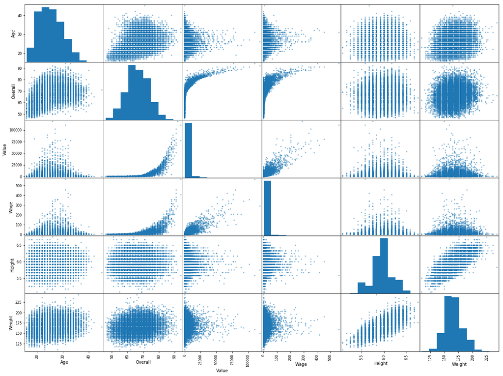

```python
muti = pd.plotting.scatter_matrix(data, alpha=0.5, figsize=(20,15), diagonal='hist')
```

By plotting scatter matrix, the bivariate relation and the single variable relation of Age, Overall, Value, Wage, Height, Weight are obtained.

I found out from the picture：

- 'Overall' is positively correlated with 'wage' and 'value'.
- 'Height' is positively correlated with 'Weight'.
- There are some differences between 'Value'and 'Wage' with other data.

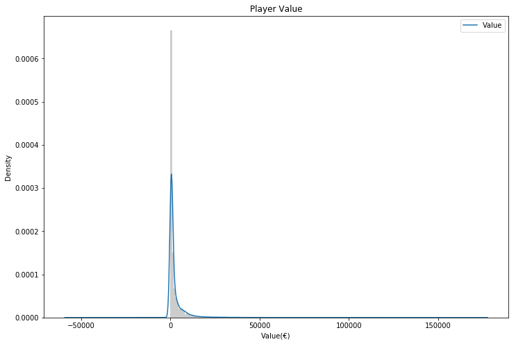

```python
data['Value'].hist(bins=int(np.sqrt(len(data))), density=True, alpha=0.4, color='grey', figsize=(12,8))
data['Value'].plot(kind='kde', title='Player Value', legend='KDE')
plt.xlabel("Value(€)")
```

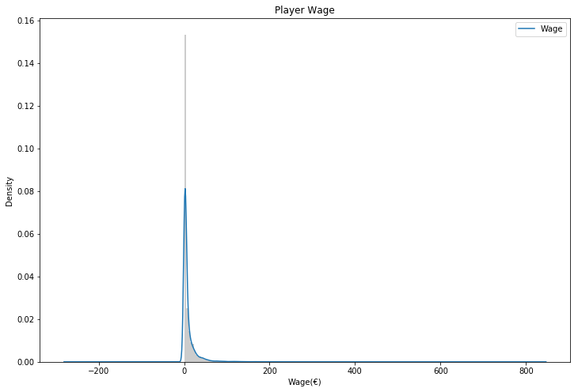

```python
data['Wage'].hist(bins=int(np.sqrt(len(data))), density=True, alpha=0.4, color='grey', figsize=(12,8))
data['Wage'].plot(kind='kde', title='Player Wage', legend='KDE')
plt.xlabel("Wage(€)")
```

```python
nation = data['Nationality'].value_counts()
nation = pd.DataFrame(nation)
nation['percentage'] = nation.values / len(data)
nation.head()
#nation.plot(kind='barh', title='Nationality', figsize=(20, 15), alpha=.8)
```

|  | Nationality | percentage |
| --- | --- | --- |
| England | 1655 | 0.092422 |
| Germany | 1195 | 0.066734 |
| Spain | 1071 | 0.059809 |
| Argentina | 935 | 0.052214 |
| France | 910 | 0.050818 |

After grouping the data according to countries, we can find that there are more excellent players in the above five countries.

```python
club = data['Club'].value_counts()
club = pd.DataFrame(club)
club['percentage'] = club.values / len(data)
club.head()
```

|  | Club | percentage |
| --- | --- | --- |
| TSG 1899 Hoffenheim | 33 | 0.001843 |
| Borussia Dortmund | 33 | 0.001843 |
| Cardiff City | 33 | 0.001843 |
| Newcastle United | 33 | 0.001843 |
| Burnley | 33 | 0.001843 |

After grouping the data according to the club, it can be found that the number of club players is approximately the same.

```python
p_foot = data['Preferred Foot'].value_counts()
p_foot = pd.DataFrame(p_foot)
p_foot['percentage'] = p_foot.values / len(data)
p_foot
```

|  | Preferred Foot | percentage |
| --- | --- | --- |
| Right | 13748 | 0.767744 |
| Left | 4159 | 0.232256 |

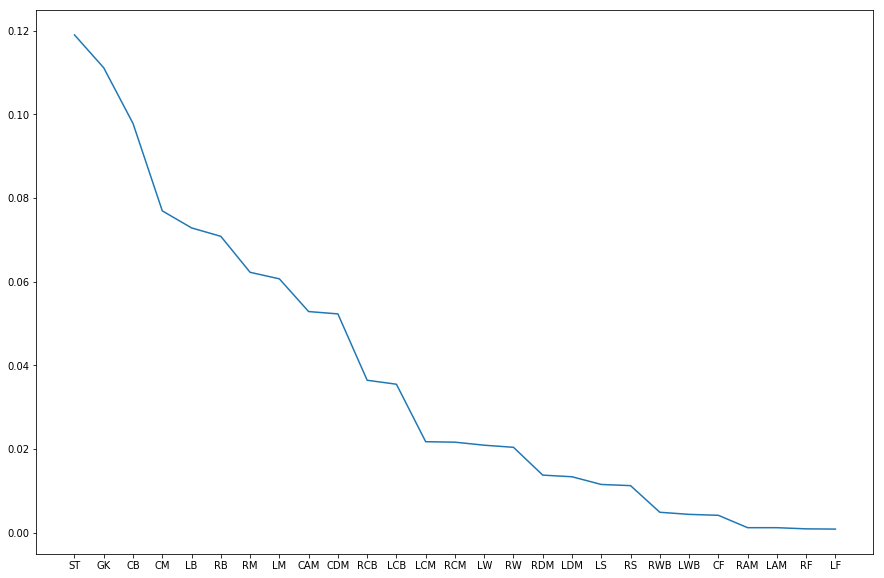

```python
position = data['Position'].value_counts()
position = pd.DataFrame(position)
position['percentage'] = position.values / len(data)
x = []
y = []
for index in position.index:
    x.append(index)
for each in position['percentage']:
    y.append(each)
#x = list(position.index)
#y = list(position['percentage'])
plt.plot(x,y)
```

After statistics of players'positions, it is found that'ST','GK','CB' are the three positions with the largest number of players, while'LF','RF','LAM'are the three positions with the least number of players.

# Data Analysis

## Q1: The effect of players' position on their wages

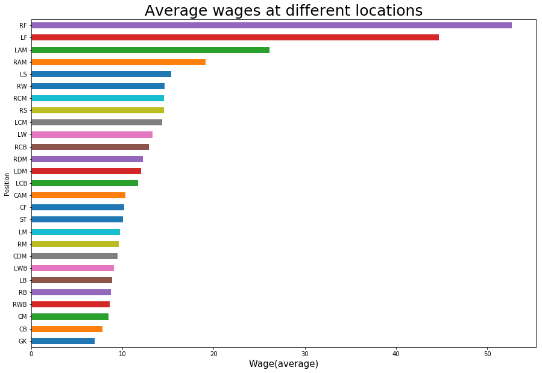

```python
q1 = data['Wage'].groupby(data['Position']).mean()
q1 = q1.sort_values(ascending=True)
q1 = pd.DataFrame(q1)
q1['amount'] = data['Position'].value_counts()
q1['Wage'].plot(kind='barh')
plt.xlabel('Wage(average)', fontsize = 15)
plt.title('Average wages at different locations', fontsize = 25)
```

According to the figure above, the top five positions with the highest average wage are'RF','LF','LAM','RAM','LS'.

After researching the different salaries of the specific location, I grouped the data again according to the more general location.

```python
Forward = []
Midfielder = []
Back = []
GK = []
for each in q1.index:
    if each[-1:] in 'FSWT':
        Forward.append(each)
    elif each[-1:] == 'M':
        Midfielder.append(each)
    elif each[-1:] == 'B':
        Back.append(each)
    elif each == 'GK':
        GK.append(each)
print(Forward)
print(Midfielder)
print(Back)
print(GK)
```

```
['ST', 'CF', 'LW', 'RS', 'RW', 'LS', 'LF', 'RF']
['CM', 'CDM', 'RM', 'LM', 'CAM', 'LDM', 'RDM', 'LCM', 'RCM', 'RAM', 'LAM']
['CB', 'RWB', 'RB', 'LB', 'LWB', 'LCB', 'RCB']
['GK']
```

```python
def p_mean(ls):
    ft = 0
    amount = 0
    for each in ls:
        amount += q1.loc[each,'amount']
    for each in ls:
        ft += q1.loc[each,'Wage'] * q1.loc[each,'amount']
    return float(round(ft/amount,2))
```

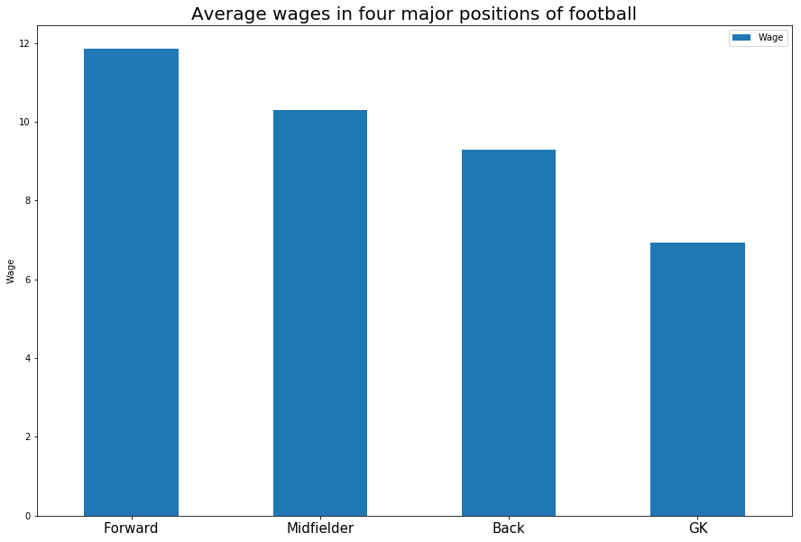

```python
Position = ['Forward','Midfielder','Back','GK']
pw = dict({'Wage':[p_mean(Forward),p_mean(Midfielder),p_mean(Back),p_mean(GK)]})
pw = pd.DataFrame(pw)
pw.index = Position
pw.plot(kind='bar')
plt.xticks(rotation=0, fontsize=15)
plt.ylabel('Wage')
plt.title('Average wages in four major positions of football',fontsize=20)
```

According to the above, the average wages of the four positions of'Forward','Midfielder','Back','GK'are obtained. The relationship between them is' Forward' > 'Midfielder' > 'Back' > 'GK'.

In summary, forward and midfield have higher wages, and among them, 'RF','LF','LAM','RAM' pay is higher than other positions in the same profession. Through the two charts, we can also find that the lower the average wage is, which to some extent reflects that the current football strategy pays more attention to attack.

## Q2: Effects of Height and Weight on Player Position

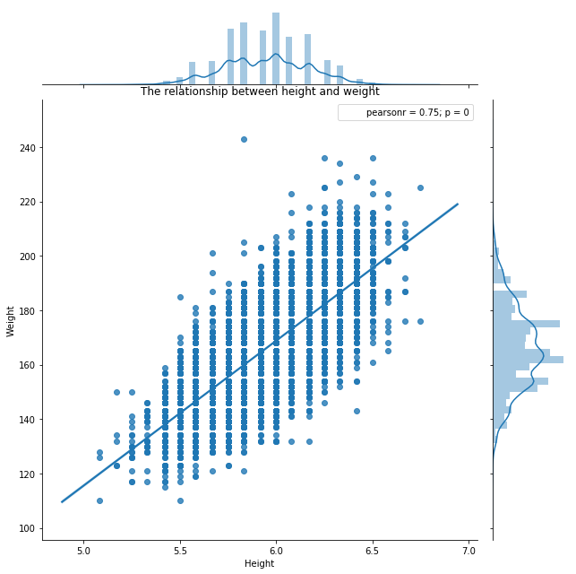

```python
j = sns.jointplot("Height", "Weight", data, kind='reg', height=9);
j.annotate(stats.pearsonr)
plt.title('The relationship between height and weight')
```

Because the pearsonr value is 0.75, which is between 0.6 and 0.8, there is a strong positive correlation between players'height and weight.

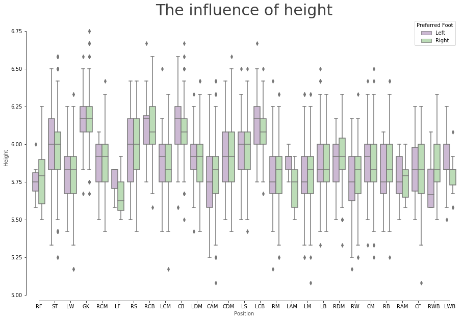

```python
sns.boxplot(x="Position", y="Height", hue="Preferred Foot", data=data, palette="PRGn")
sns.despine(offset=10, trim=True)

plt.title('The influence of height', alpha=0.75, fontsize=30)
plt.ylabel('Height', alpha=0.75)
plt.xlabel('Position', alpha=0.75)
```

As can be seen from the figure above, the preferred foot has little effect on the position of football players. The height of football players is mainly between 6.25 and 5.5 feet, which is similar to the general population. However, players in the positions of'GK','RCB','CB','LCB'tend to have higher stature,'RF','LF','LAM','RAM' tend to have lower stature.

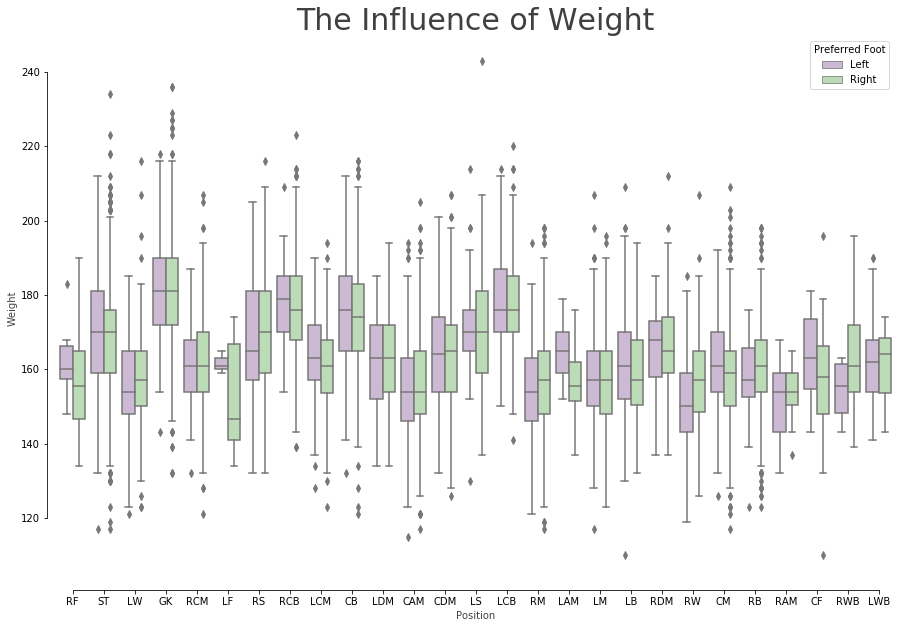

```python
sns.boxplot(x="Position", y="Weight", hue="Preferred Foot", data=data, palette="PRGn")
sns.despine(offset=10, trim=True)

plt.title('The Influence of Weight', alpha=0.75, fontsize=30)
plt.ylabel('Weight', alpha=0.75)
plt.xlabel('Position', alpha=0.75)
```

Because height and weight are positively correlated, the results are almost the same as height.

```
(5.5, 6.3)
```

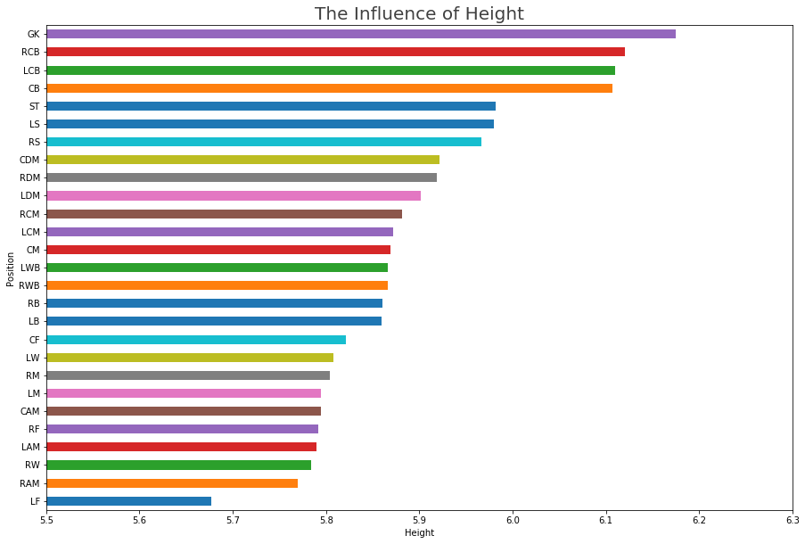

```python
h = data['Height'].groupby(data['Position']).mean()
h = h.sort_values(ascending=True)
h = pd.DataFrame(h)
h['amount'] = data['Position'].value_counts()
h['Height'].plot(kind='barh')

plt.xlabel('Height')
plt.ylabel('Position')
plt.title('The Influence of Height', alpha=0.75, fontsize=20)

x_major_locator=MultipleLocator(0.1)
ax=plt.gca()
ax.xaxis.set_major_locator(x_major_locator)
plt.xlim(5.5,6.3)
```

```
(148, 182)
```

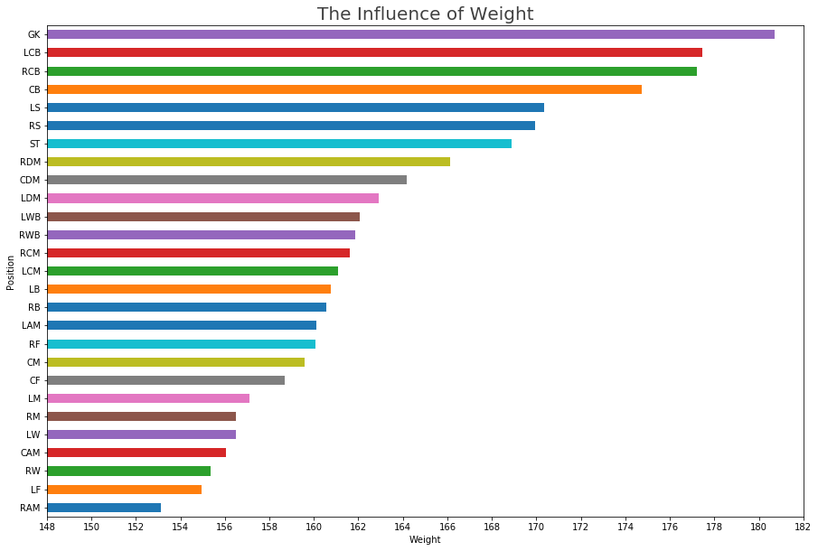

```python
w = data['Weight'].groupby(data['Position']).mean()
w = w.sort_values(ascending=True)
w = pd.DataFrame(w)
w['amount'] = data['Position'].value_counts()
w['Weight'].plot(kind='barh')

plt.xlabel('Weight')
plt.ylabel('Position')
plt.title('The Influence of Weight', alpha=0.75, fontsize=20)

x_major_locator=MultipleLocator(2)
ax=plt.gca()
ax.xaxis.set_major_locator(x_major_locator)
plt.xlim(148,182)
```

The same results can also be obtained by calculating the average height and weight of each position.

To sum up, offensive players are lower in height and lighter in weight than defensive players. On the contrary, it can be inferred that higher players are more suitable for defensive players and lower players are more suitable for offensive players.

## Q3: Different clubs attach importance to the types of players

On this issue, I will select the top five clubs with players'total score to study. First of all, I need to extract the data about these five clubs.

```python
c = data['Overall'].groupby(data['Club']).mean()
cc = pd.DataFrame(c)
ccc = cc.query('Overall > %f' % c.mean()).sort_values('Overall',ascending=False).head()
ccc
```

| Club | Overall |
| --- | --- |
| Juventus | 82.280000 |
| Napoli | 80.000000 |
| Inter | 79.750000 |
| Real Madrid | 78.242424 |
| Milan | 78.074074 |

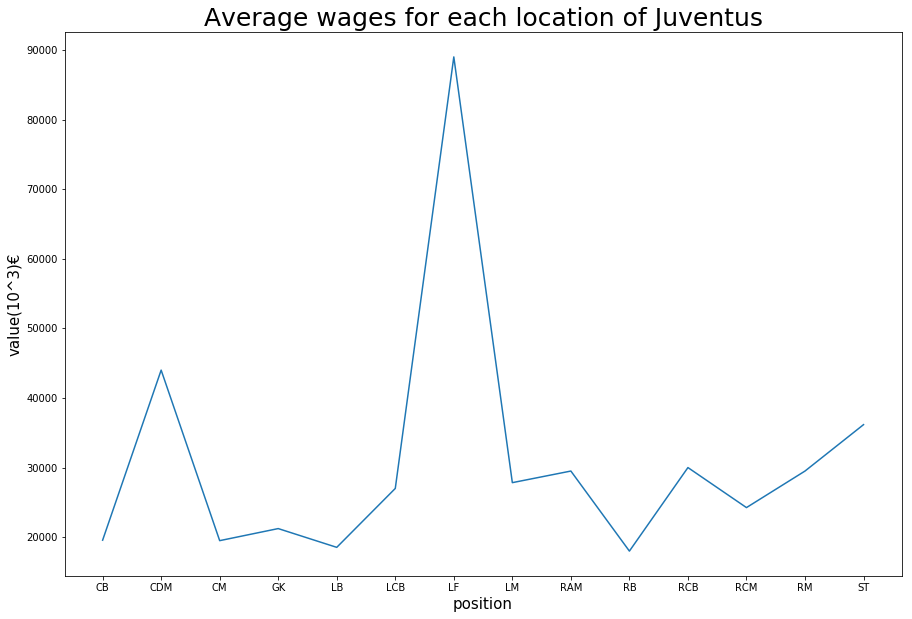

```python
Juventus = data[data['Club'] == 'Juventus'][['Club','Overall','Value','Position']]
j = Juventus[['Position','Value']].groupby('Position').mean()
x = j.index
y = j.values
plt.plot(x,y)
plt.xlabel('position', fontsize = 15)
plt.ylabel('value(10^3)€', fontsize = 15)
plt.title('Average wages for each location of Juventus', fontsize = 25)
```

Juventus pays more attention to LF and is willing to invest more in recruiting players.

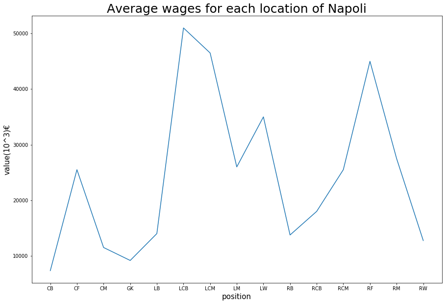

```python
Napoli = data[data['Club'] == 'Napoli'][['Club','Overall','Value','Position']]
n = Napoli[['Position','Value']].groupby('Position').mean()
x = n.index
y = n.values
plt.plot(x,y)
plt.xlabel('position', fontsize = 15)
plt.ylabel('value(10^3)€', fontsize = 15)
plt.title('Average wages for each location of Napoli', fontsize = 25)
```

Napoli pays more attention to'LCB','LCM','RF', and is willing to invest more in recruiting players.

[figure not shown]

```python
Inter = data[data['Club'] == 'Inter'][['Club','Overall','Value','Position']]
i = Inter[['Position','Value']].groupby('Position').mean()
x = i.index
y = i.values
plt.plot(x,y)
plt.xlabel('position', fontsize = 15)
plt.ylabel('value(10^3)€', fontsize = 15)
plt.title('Average wages for each location of Inter', fontsize = 25)
```

Inter pays more attention to'ST','LCB', and is willing to invest more in recruiting players.

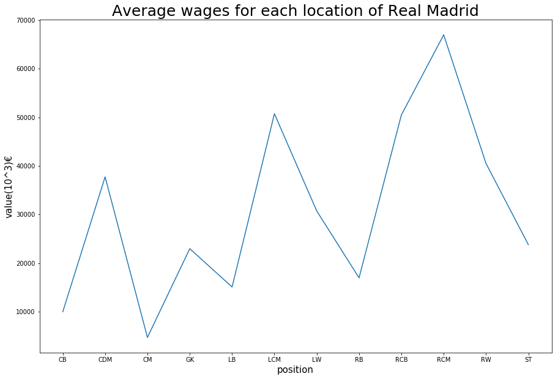

```python
Real_Madrid = data[data['Club'] == 'Real Madrid'][['Club','Overall','Value','Position']]
r = Real_Madrid[['Position','Value']].groupby('Position').mean()
x = r.index
y = r.values
plt.plot(x,y)
plt.xlabel('position', fontsize = 15)
plt.ylabel('value(10^3)€', fontsize = 15)
plt.title('Average wages for each location of Real Madrid', fontsize = 25)
```

Real Madrid pays more attention to'RCM','LCM','RCB', and is willing to invest more in recruiting players.

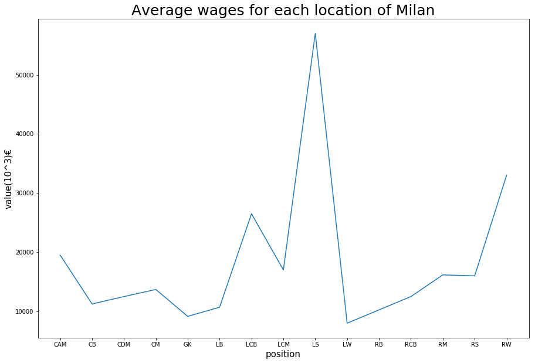

```python
Milan = data[data['Club'] == 'Milan'][['Club','Overall','Value','Position']]
m = Milan[['Position','Value']].groupby('Position').mean()
x = m.index
y = m.values
plt.plot(x,y)
plt.xlabel('position', fontsize = 15)
plt.ylabel('value(10^3)€', fontsize = 15)
plt.title('Average wages for each location of Milan', fontsize = 25)
```

Milan pays more attention to'LS'and is willing to invest more in recruiting players.

## Conclusion

Throughout the project, I spent a lot of time on DATA WRANGLING. I think this is a very important step. Proper data wrangling will make data more intuitive and less error in EDA and Analysis. After studying the effects of different factors on players'positions, I found that Front-court players tend to get higher wages, and they have smaller size and more flexible operation. For teams with tactical bias to attack, the quality of Front-court players is relatively high.